# Logistic Regression Analysis - Weather Prediction

Data Science Analysis

2025-09-06

# Introduction

This analysis implements a logistic regression model to predict whether it will rain tomorrow in Australia based on weather data. The analysis follows a comprehensive approach including data exploration, preprocessing, model building, evaluation, and visualization.

## Problem Statement

Build a binary classification model to predict whether it will rain tomorrow (Yes/No) based on various weather features including temperature, humidity, pressure, wind conditions, and location.

## Dataset

The Australian weather dataset contains historical weather observations from multiple locations across Australia.

- **Source**: Australian Bureau of Meteorology
- **Observations**: 142,193
- **Variables**: 24 (including target variable RainTomorrow)
- **Time Period**: 2007-2017
- **Target Variable**: RainTomorrow (Yes/No)

# Data Loading and Understanding

```r
# Load required libraries
library(ggplot2)
library(dplyr)
library(corrplot)
library(gridExtra)
library(caret)
library(pROC)
library(VIM)

# Set theme for white background plots
theme_set(theme_minimal() +
          theme(panel.background = element_rect(fill = "white", color = NA),
                plot.background = element_rect(fill = "white", color = NA)))
```

```r
# Load the dataset
weather_data <- read.csv("Weather-Dataset/weatherAUS.csv")

# Display basic information about the dataset
cat("Dataset Information:\n")
```

```
## Dataset Information:
```

```r
cat("Shape:", nrow(weather_data), "rows,", ncol(weather_data), "columns\n")
```

```
## Shape: 142193 rows, 24 columns
```

```r
cat("Column names:", paste(names(weather_data), collapse = ", "), "\n")
```

```
## Column names: Date, Location, MinTemp, MaxTemp, Rainfall, Evaporation, Sunshine, WindGustDir, WindGustSpeed, WindDir9am, WindDir3pm, WindSpeed9am, WindSpeed3pm, Humidity9am, Humidity3pm, Pressure9am, Pressure3pm, Cloud9am, Cloud3pm, Temp9am, Temp3pm, RainToday, RISK_MM, RainTomorrow
```

```r
# Display first few rows
head(weather_data, 10)
```

```
##          Date Location MinTemp MaxTemp Rainfall Evaporation Sunshine
## 1  2008-12-01   Albury    13.4    22.9      0.6          NA       NA
## 2  2008-12-02   Albury     7.4    25.1      0.0          NA       NA
## 3  2008-12-03   Albury    12.9    25.7      0.0          NA       NA
## 4  2008-12-04   Albury     9.2    28.0      0.0          NA       NA
## 5  2008-12-05   Albury    17.5    32.3      1.0          NA       NA
## 6  2008-12-06   Albury    14.6    29.7      0.2          NA       NA
## 7  2008-12-07   Albury    14.3    25.0      0.0          NA       NA
## 8  2008-12-08   Albury     7.7    26.7      0.0          NA       NA
## 9  2008-12-09   Albury     9.7    31.9      0.0          NA       NA
## 10 2008-12-10   Albury    13.1    30.1      1.4          NA       NA
##    WindGustDir WindGustSpeed WindDir9am WindDir3pm WindSpeed9am WindSpeed3pm
## 1            W            44          W        WNW           20           24
## 2          WNW            44        NNW        WSW            4           22
## 3          WSW            46          W        WSW           19           26
```

[output cut: 29 more lines]

```r
# Data summary
summary(weather_data)
```

```
##      Date             Location            MinTemp         MaxTemp
##  Length:142193      Length:142193      Min.   :-8.50   Min.   :-4.80
##  Class :character   Class :character   1st Qu.: 7.60   1st Qu.:17.90
##  Mode  :character   Mode  :character   Median :12.00   Median :22.60
##                                        Mean   :12.19   Mean   :23.23
##                                        3rd Qu.:16.80   3rd Qu.:28.20
##                                        Max.   :33.90   Max.   :48.10
##                                        NA's   :637     NA's   :322
##     Rainfall       Evaporation        Sunshine      WindGustDir
##  Min.   :  0.00   Min.   :  0.00   Min.   : 0.000   Length:142193
##  1st Qu.:  0.00   1st Qu.:  2.60   1st Qu.: 4.900   Class :character
##  Median :  0.00   Median :  4.80   Median : 8.500   Mode  :character
##  Mean   :  2.35   Mean   :  5.47   Mean   : 7.625
##  3rd Qu.:  0.80   3rd Qu.:  7.40   3rd Qu.:10.600
##  Max.   :371.00   Max.   :145.00   Max.   :14.500
##  NA's   :1406     NA's   :60843    NA's   :67816
##  WindGustSpeed     WindDir9am         WindDir3pm         WindSpeed9am
##  Min.   :  6.00   Length:142193      Length:142193      Min.   :  0
##  1st Qu.: 31.00   Class :character   Class :character   1st Qu.:  7
##  Median : 39.00   Mode  :character   Mode  :character   Median : 13
##  Mean   : 39.98                                         Mean   : 14
##  3rd Qu.: 48.00                                         3rd Qu.: 19
##  Max.   :135.00                                         Max.   :130
##  NA's   :9270                                           NA's   :1348
##   WindSpeed3pm    Humidity9am      Humidity3pm      Pressure9am
##  Min.   : 0.00   Min.   :  0.00   Min.   :  0.00   Min.   : 980.5
##  1st Qu.:13.00   1st Qu.: 57.00   1st Qu.: 37.00   1st Qu.:1012.9
##  Median :19.00   Median : 70.00   Median : 52.00   Median :1017.6
##  Mean   :18.64   Mean   : 68.84   Mean   : 51.48   Mean   :1017.7
##  3rd Qu.:24.00   3rd Qu.: 83.00   3rd Qu.: 66.00   3rd Qu.:1022.4
##  Max.   :87.00   Max.   :100.00   Max.   :100.00   Max.   :1041.0
##  NA's   :2630    NA's   :1774     NA's   :3610     NA's   :14014
##   Pressure3pm        Cloud9am        Cloud3pm        Temp9am
##  Min.   : 977.1   Min.   :0.000   Min.   :0.000   Min.   :-7.20
##  1st Qu.:1010.4   1st Qu.:1.000   1st Qu.:2.000   1st Qu.:12.30
##  Median :1015.2   Median :5.000   Median :5.000   Median :16.70
##  Mean   :1015.3   Mean   :4.437   Mean   :4.503   Mean   :16.99
##  3rd Qu.:1020.0   3rd Qu.:7.000   3rd Qu.:7.000   3rd Qu.:21.60
##  Max.   :1039.6   Max.   :9.000   Max.   :9.000   Max.   :40.20
##  NA's   :13981    NA's   :53657   NA's   :57094   NA's   :904
##     Temp3pm       RainToday            RISK_MM        RainTomorrow
##  Min.   :-5.40   Length:142193      Min.   :  0.000   Length:142193
##  1st Qu.:16.60   Class :character   1st Qu.:  0.000   Class :character
##  Median :21.10   Mode  :character   Median :  0.000   Mode  :character
##  Mean   :21.69                      Mean   :  2.361
##  3rd Qu.:26.40                      3rd Qu.:  0.800
##  Max.   :46.70                      Max.   :371.000
##  NA's   :2726
```

```r
# Check for missing values
missing_values <- colSums(is.na(weather_data))
cat("Missing values per column:\n")
```

```
## Missing values per column:
```

```r
print(missing_values)
```

```
##          Date      Location       MinTemp       MaxTemp      Rainfall
##             0             0           637           322          1406
##   Evaporation      Sunshine   WindGustDir WindGustSpeed    WindDir9am
##         60843         67816          9330          9270         10013
##    WindDir3pm  WindSpeed9am  WindSpeed3pm   Humidity9am   Humidity3pm
##          3778          1348          2630          1774          3610
##   Pressure9am   Pressure3pm      Cloud9am      Cloud3pm       Temp9am
##         14014         13981         53657         57094           904
##       Temp3pm     RainToday       RISK_MM  RainTomorrow
##          2726          1406             0             0
```

# Data Preprocessing

## Feature Engineering

```r
# Drop RISK_MM variable as mentioned in the reference notebook
weather_data <- weather_data[, !names(weather_data) %in% c("RISK_MM")]

# Feature Engineering - Extract date components
weather_data$Date <- as.Date(weather_data$Date)
weather_data$Year <- as.numeric(format(weather_data$Date, "%Y"))
weather_data$Month <- as.numeric(format(weather_data$Date, "%m"))
weather_data$Day <- as.numeric(format(weather_data$Date, "%d"))

# Drop the original Date variable
weather_data <- weather_data[, !names(weather_data) %in% c("Date")]

cat("After feature engineering:\n")
```

```
## After feature engineering:
```

```r
cat("Shape:", nrow(weather_data), "rows,", ncol(weather_data), "columns\n")
```

```
## Shape: 142193 rows, 25 columns
```

## Variable Types Analysis

```r
# Identify categorical and numerical variables
categorical_vars <- names(weather_data)[sapply(weather_data, is.character)]
numerical_vars <- names(weather_data)[sapply(weather_data, is.numeric)]

cat("Categorical variables:", paste(categorical_vars, collapse = ", "), "\n")
```

```
## Categorical variables: Location, WindGustDir, WindDir9am, WindDir3pm, RainToday, RainTomorrow
```

```r
cat("Numerical variables:", paste(numerical_vars, collapse = ", "), "\n")
```

```
## Numerical variables: MinTemp, MaxTemp, Rainfall, Evaporation, Sunshine, WindGustSpeed, WindSpeed9am, WindSpeed3pm, Humidity9am, Humidity3pm, Pressure9am, Pressure3pm, Cloud9am, Cloud3pm, Temp9am, Temp3pm, Year, Month, Day
```

# Exploratory Data Analysis

## Target Variable Analysis

```r
# Target variable distribution
target_dist <- table(weather_data$RainTomorrow)
print(target_dist)
```

```
##
##     No    Yes
## 110316  31877
```

```r
cat("Proportions:\n")
```

```
## Proportions:
```

```r
print(prop.table(target_dist))
```

```
##
##        No       Yes
## 0.7758188 0.2241812
```

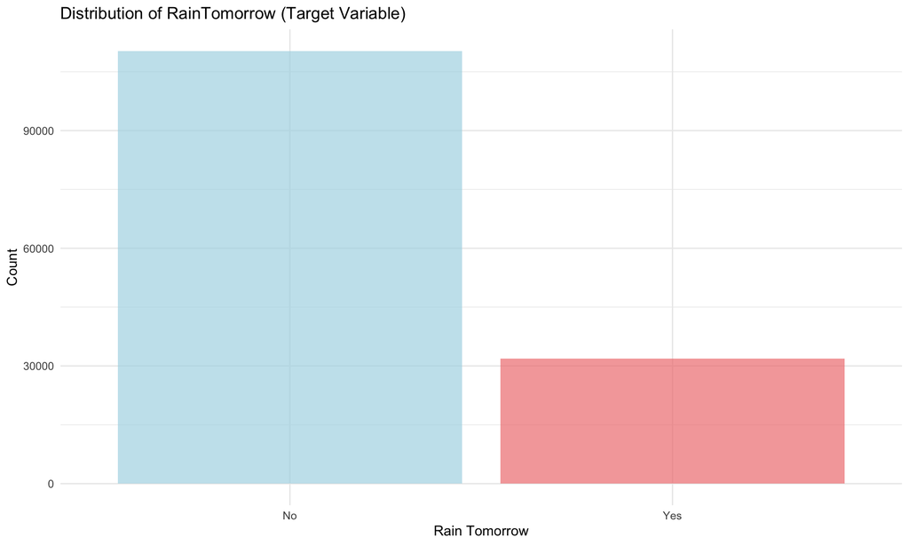

```r
# Create target variable distribution plot
p_target <- ggplot(weather_data, aes(x = RainTomorrow, fill = RainTomorrow)) +
  geom_bar(alpha = 0.7) +
  scale_fill_manual(values = c("No" = "lightblue", "Yes" = "lightcoral")) +
  labs(title = "Distribution of RainTomorrow (Target Variable)",
       x = "Rain Tomorrow",
       y = "Count") +
  theme_minimal() +
  theme(panel.background = element_rect(fill = "white", color = NA),
        plot.background = element_rect(fill = "white", color = NA),
        legend.position = "none")

print(p_target)
```

## Missing Values Analysis

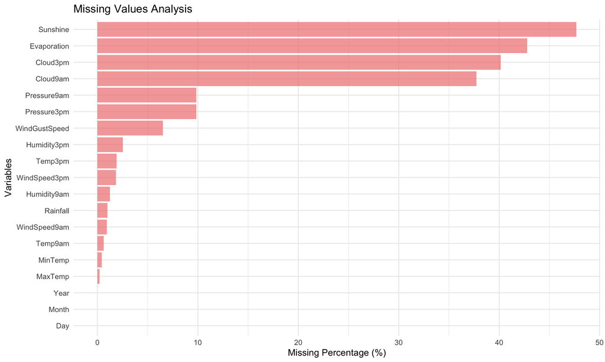

```r
# Missing values analysis for numerical variables
missing_data <- weather_data[, numerical_vars]
missing_summary <- colSums(is.na(missing_data))
missing_df <- data.frame(Variable = names(missing_summary), Missing_Count = missing_summary)
missing_df$Missing_Percentage <- (missing_df$Missing_Count / nrow(weather_data)) * 100

p_missing <- ggplot(missing_df, aes(x = reorder(Variable, Missing_Percentage), y = Missing_Percentage)) +
  geom_bar(stat = "identity", fill = "lightcoral", alpha = 0.7) +
  coord_flip() +
  labs(title = "Missing Values Analysis",
       x = "Variables",
       y = "Missing Percentage (%)") +
  theme_minimal() +
  theme(panel.background = element_rect(fill = "white", color = NA),
        plot.background = element_rect(fill = "white", color = NA))

print(p_missing)
```

## Correlation Analysis

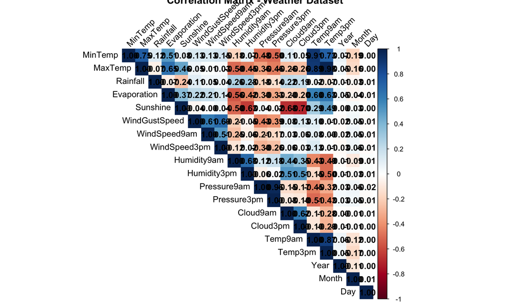

```r
# Correlation analysis for numerical variables
numerical_data <- weather_data[, numerical_vars]
correlation_matrix <- cor(numerical_data, use = "complete.obs")

# Create correlation heatmap
corrplot(correlation_matrix, method = "color", type = "upper",
         addCoef.col = "black", tl.col = "black", tl.srt = 45,
         title = "Correlation Matrix - Weather Dataset")
```

# Data Preprocessing

## Missing Value Imputation

```r
# Handle missing values in numerical variables (use median imputation)
for (var in numerical_vars) {
  if (sum(is.na(weather_data[[var]])) > 0) {
    median_val <- median(weather_data[[var]], na.rm = TRUE)
    weather_data[[var]][is.na(weather_data[[var]])] <- median_val
    cat("Imputed missing values in", var, "with median:", round(median_val, 2), "\n")
  }
}
```

```
## Imputed missing values in MinTemp with median: 12
## Imputed missing values in MaxTemp with median: 22.6
## Imputed missing values in Rainfall with median: 0
## Imputed missing values in Evaporation with median: 4.8
## Imputed missing values in Sunshine with median: 8.5
## Imputed missing values in WindGustSpeed with median: 39
## Imputed missing values in WindSpeed9am with median: 13
## Imputed missing values in WindSpeed3pm with median: 19
## Imputed missing values in Humidity9am with median: 70
## Imputed missing values in Humidity3pm with median: 52
## Imputed missing values in Pressure9am with median: 1017.6
## Imputed missing values in Pressure3pm with median: 1015.2
## Imputed missing values in Cloud9am with median: 5
## Imputed missing values in Cloud3pm with median: 5
## Imputed missing values in Temp9am with median: 16.7
## Imputed missing values in Temp3pm with median: 21.1
```

```r
# Handle missing values in categorical variables (use mode)
for (var in categorical_vars) {
  if (sum(is.na(weather_data[[var]])) > 0) {
    mode_val <- names(sort(table(weather_data[[var]]), decreasing = TRUE))[1]
    weather_data[[var]][is.na(weather_data[[var]])] <- mode_val
    cat("Imputed missing values in", var, "with mode:", mode_val, "\n")
  }
}
```

```
## Imputed missing values in WindGustDir with mode: W
## Imputed missing values in WindDir9am with mode: N
## Imputed missing values in WindDir3pm with mode: SE
## Imputed missing values in RainToday with mode: No
```

```r
# Check if all missing values are handled
cat("\nMissing values after imputation:\n")
```

```
##
## Missing values after imputation:
```

```r
missing_after <- colSums(is.na(weather_data))
print(missing_after)
```

```
##      Location       MinTemp       MaxTemp      Rainfall   Evaporation
##             0             0             0             0             0
##      Sunshine   WindGustDir WindGustSpeed    WindDir9am    WindDir3pm
##             0             0             0             0             0
##  WindSpeed9am  WindSpeed3pm   Humidity9am   Humidity3pm   Pressure9am
##             0             0             0             0             0
##   Pressure3pm      Cloud9am      Cloud3pm       Temp9am       Temp3pm
##             0             0             0             0             0
##     RainToday  RainTomorrow          Year         Month           Day
##             0             0             0             0             0
```

## Feature Engineering - Dummy Variables

```r
# Convert categorical variables to factors
for (var in categorical_vars) {
  weather_data[[var]] <- as.factor(weather_data[[var]])
}

# Create dummy variables for Location (high cardinality)
location_dummies <- model.matrix(~ Location - 1, data = weather_data)
location_dummies <- as.data.frame(location_dummies)

# Create dummy variables for wind directions
wind_gust_dummies <- model.matrix(~ WindGustDir - 1, data = weather_data)
wind_gust_dummies <- as.data.frame(wind_gust_dummies)

wind_dir9am_dummies <- model.matrix(~ WindDir9am - 1, data = weather_data)
wind_dir9am_dummies <- as.data.frame(wind_dir9am_dummies)

wind_dir3pm_dummies <- model.matrix(~ WindDir3pm - 1, data = weather_data)
wind_dir3pm_dummies <- as.data.frame(wind_dir3pm_dummies)

# Create dummy variables for RainToday
rain_today_dummies <- model.matrix(~ RainToday - 1, data = weather_data)
rain_today_dummies <- as.data.frame(rain_today_dummies)

# Combine all features
weather_processed <- cbind(
  weather_data[, numerical_vars],
  location_dummies,
  wind_gust_dummies,
  wind_dir9am_dummies,
  wind_dir3pm_dummies,
  rain_today_dummies
)

# Add target variable
weather_processed$RainTomorrow <- weather_data$RainTomorrow

cat("Processed dataset shape:", nrow(weather_processed), "rows,", ncol(weather_processed), "columns\n")
```

```
## Processed dataset shape: 142193 rows, 119 columns
```

# Model Building

## Train-Test Split

```r
# Prepare features and target
X <- weather_processed[, !names(weather_processed) %in% c("RainTomorrow")]
y <- weather_processed$RainTomorrow

# Split the data
set.seed(100)  # For reproducibility
train_indices <- createDataPartition(y, p = 0.8, list = FALSE)
X_train <- X[train_indices, ]
X_test <- X[-train_indices, ]
y_train <- y[train_indices]
y_test <- y[-train_indices]

cat("Train set size:", nrow(X_train), "observations\n")
```

```
## Train set size: 113755 observations
```

```r
cat("Test set size:", nrow(X_test), "observations\n")
```

```
## Test set size: 28438 observations
```

```r
# Check class distribution in train and test sets
cat("\nClass distribution in training set:\n")
```

```
##
## Class distribution in training set:
```

```r
print(table(y_train))
```

```
## y_train
##    No   Yes
## 88253 25502
```

```r
cat("Class distribution in test set:\n")
```

```
## Class distribution in test set:
```

```r
print(table(y_test))
```

```
## y_test
##    No   Yes
## 22063  6375
```

## Feature Scaling

```r
# Scale numerical features
preprocess_params <- preProcess(X_train, method = c("center", "scale"))
X_train_scaled <- predict(preprocess_params, X_train)
X_test_scaled <- predict(preprocess_params, X_test)

cat("Features scaled using standardization\n")
```

```
## Features scaled using standardization
```

## Building Logistic Regression Model

```r
# Build Logistic Regression Model
train_data <- data.frame(X_train_scaled, RainTomorrow = y_train)

# Fit logistic regression model
logistic_model <- glm(RainTomorrow ~ ., data = train_data, family = binomial)

# Display model summary
summary(logistic_model)
```

```
##
## Call:
## glm(formula = RainTomorrow ~ ., family = binomial, data = train_data)
##
## Coefficients: (5 not defined because of singularities)
##                            Estimate Std. Error  z value Pr(>|z|)
## (Intercept)              -1.8726872  0.0114585 -163.432  < 2e-16 ***
## MinTemp                   0.1602331  0.0306242    5.232 1.67e-07 ***
## MaxTemp                  -0.4281328  0.0432952   -9.889  < 2e-16 ***
## Rainfall                  0.0837659  0.0102507    8.172 3.04e-16 ***
## Evaporation               0.0134394  0.0122253    1.099 0.271632
## Sunshine                 -0.2976185  0.0123221  -24.153  < 2e-16 ***
## WindGustSpeed             0.7140847  0.0138682   51.491  < 2e-16 ***
## WindSpeed9am             -0.0440919  0.0129891   -3.395 0.000687 ***
## WindSpeed3pm             -0.1698598  0.0127621  -13.310  < 2e-16 ***
## Humidity9am               0.0963724  0.0189185    5.094 3.50e-07 ***
## Humidity3pm               1.1915960  0.0207569   57.407  < 2e-16 ***
## Pressure9am               0.9453712  0.0405825   23.295  < 2e-16 ***
## Pressure3pm              -1.3371817  0.0405323  -32.990  < 2e-16 ***
## Cloud9am                  0.0015337  0.0130380    0.118 0.906358
## Cloud3pm                  0.2729676  0.0131414   20.772  < 2e-16 ***
## Temp9am                   0.1812853  0.0427822    4.237 2.26e-05 ***
## Temp3pm                   0.1739503  0.0432395    4.023 5.75e-05 ***
## Year                      0.0477800  0.0092802    5.149 2.62e-07 ***
## Month                     0.0312484  0.0097918    3.191 0.001416 **
## Day                      -0.0125741  0.0089832   -1.400 0.161592
## LocationAdelaide          0.1426382  0.0178599    7.987 1.39e-15 ***
## LocationAlbany            0.0211603  0.0176036    1.202 0.229345
## LocationAlbury            0.1119782  0.0181012    6.186 6.16e-10 ***
## LocationAliceSprings      0.0253203  0.0211279    1.198 0.230749
## LocationBadgerysCreek     0.0757178  0.0175898    4.305 1.67e-05 ***
## LocationBallarat         -0.0047439  0.0179702   -0.264 0.791789
## LocationBendigo           0.0765132  0.0181916    4.206 2.60e-05 ***
## LocationBrisbane          0.1029298  0.0183888    5.597 2.18e-08 ***
## LocationCairns            0.0212486  0.0177362    1.198 0.230902
## LocationCanberra          0.0466843  0.0191365    2.440 0.014706 *
## LocationCobar             0.0881403  0.0188691    4.671 3.00e-06 ***
## LocationCoffsHarbour      0.0303418  0.0173762    1.746 0.080781 .
## LocationDartmoor          0.0413276  0.0172633    2.394 0.016668 *
## LocationDarwin           -0.0553015  0.0188532   -2.933 0.003354 **
```

[output cut: 80 more lines]

```
## WindDir3pmW               0.0185394  0.0124894    1.484 0.137702
## WindDir3pmWNW             0.0539234  0.0126165    4.274 1.92e-05 ***
## WindDir3pmWSW                    NA         NA       NA       NA
## RainTodayNo              -0.1776466  0.0101511  -17.500  < 2e-16 ***
## RainTodayYes                     NA         NA       NA       NA
## ---
## Signif. codes:  0 '***' 0.001 '**' 0.01 '*' 0.05 '.' 0.1 ' ' 1
##
## (Dispersion parameter for binomial family taken to be 1)
##
##     Null deviance: 121070  on 113754  degrees of freedom
## Residual deviance:  80061  on 113641  degrees of freedom
## AIC: 80289
##
## Number of Fisher Scoring iterations: 6
```

# Model Evaluation

## Predictions and Accuracy

```r
# Predictions on training set
y_train_pred_prob <- predict(logistic_model, newdata = X_train_scaled, type = "response")
y_train_pred <- ifelse(y_train_pred_prob > 0.5, "Yes", "No")

# Predictions on test set
y_test_pred_prob <- predict(logistic_model, newdata = X_test_scaled, type = "response")
y_test_pred <- ifelse(y_test_pred_prob > 0.5, "Yes", "No")

# Calculate accuracy
train_accuracy <- mean(y_train_pred == y_train)
test_accuracy <- mean(y_test_pred == y_test)

cat("Training Accuracy:", round(train_accuracy, 4), "\n")
```

```
## Training Accuracy: 0.848
```

```r
cat("Test Accuracy:", round(test_accuracy, 4), "\n")
```

```
## Test Accuracy: 0.8494
```

## Confusion Matrix

```r
# Confusion Matrix
confusion_matrix <- table(Actual = y_test, Predicted = y_test_pred)
print(confusion_matrix)
```

```
##       Predicted
## Actual    No   Yes
##    No  20863  1200
##    Yes  3083  3292
```

```r
# Calculate additional metrics
TP <- confusion_matrix[2, 2]  # True Positives
TN <- confusion_matrix[1, 1]  # True Negatives
FP <- confusion_matrix[1, 2]  # False Positives
FN <- confusion_matrix[2, 1]  # False Negatives

precision <- TP / (TP + FP)
recall <- TP / (TP + FN)
f1_score <- 2 * (precision * recall) / (precision + recall)

cat("\nPerformance Metrics:\n")
```

```
##
## Performance Metrics:
```

```r
cat("Precision:", round(precision, 4), "\n")
```

```
## Precision: 0.7329
```

```r
cat("Recall (Sensitivity):", round(recall, 4), "\n")
```

```
## Recall (Sensitivity): 0.5164
```

```r
cat("F1-Score:", round(f1_score, 4), "\n")
```

```
## F1-Score: 0.6059
```

## ROC Curve and AUC

```r
# ROC Curve
roc_obj <- roc(y_test, y_test_pred_prob)
auc_score <- auc(roc_obj)

cat("AUC Score:", round(auc_score, 4), "\n")
```

```
## AUC Score: 0.8707
```

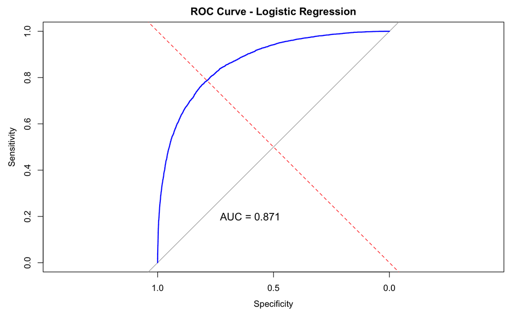

```r
# Plot ROC Curve
plot(roc_obj, main = "ROC Curve - Logistic Regression",
     col = "blue", lwd = 2)
abline(a = 0, b = 1, col = "red", lty = 2)
text(0.6, 0.2, paste("AUC =", round(auc_score, 3)), cex = 1.2)
```

## Feature Importance

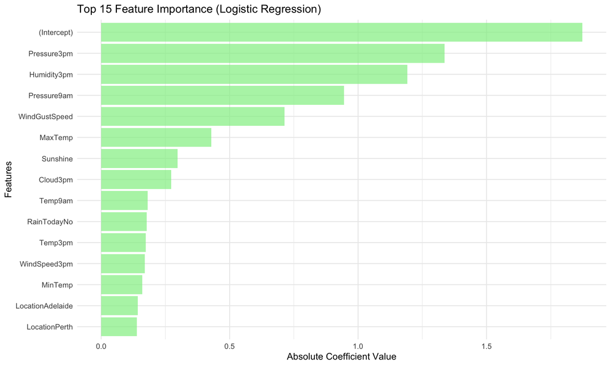

```r
# Get coefficients
coefficients <- coef(logistic_model)
coefficients <- coefficients[!is.na(coefficients)]
coefficients <- coefficients[abs(coefficients) > 0.1]  # Filter significant coefficients

# Create feature importance plot
if (length(coefficients) > 0) {
  importance_df <- data.frame(
    Feature = names(coefficients),
    Coefficient = abs(coefficients)
  )
  importance_df <- importance_df[order(importance_df$Coefficient, decreasing = TRUE), ]
  importance_df <- head(importance_df, 15)  # Top 15 features

  p_importance <- ggplot(importance_df, aes(x = reorder(Feature, Coefficient), y = Coefficient)) +
    geom_bar(stat = "identity", fill = "lightgreen", alpha = 0.7) +
    coord_flip() +
    labs(title = "Top 15 Feature Importance (Logistic Regression)",
         x = "Features",
         y = "Absolute Coefficient Value") +
    theme_minimal() +
    theme(panel.background = element_rect(fill = "white", color = NA),
          plot.background = element_rect(fill = "white", color = NA))

  print(p_importance)
}
```

## Prediction Probability Distribution

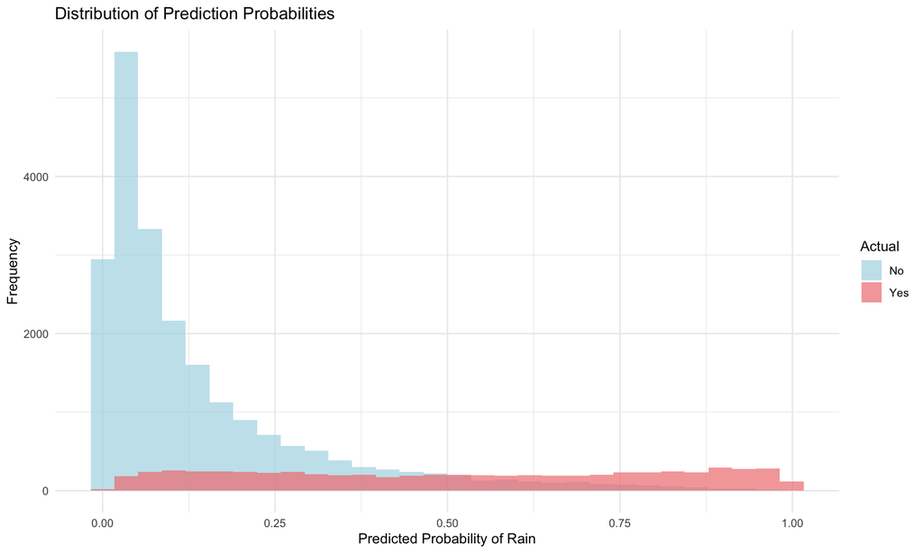

```r
# Prediction Probability Distribution
prob_df <- data.frame(Probability = y_test_pred_prob, Actual = y_test)

p_prob_dist <- ggplot(prob_df, aes(x = Probability, fill = Actual)) +
  geom_histogram(bins = 30, alpha = 0.7, position = "identity") +
  scale_fill_manual(values = c("No" = "lightblue", "Yes" = "lightcoral")) +
  labs(title = "Distribution of Prediction Probabilities",
       x = "Predicted Probability of Rain",
       y = "Frequency") +
  theme_minimal() +
  theme(panel.background = element_rect(fill = "white", color = NA),
        plot.background = element_rect(fill = "white", color = NA))

print(p_prob_dist)
```

# Cross-Validation

```r
# Perform 5-fold cross-validation
cv_results <- train(
  RainTomorrow ~ .,
  data = train_data,
  method = "glm",
  family = "binomial",
  trControl = trainControl(method = "cv", number = 5)
)

cat("Cross-validation results:\n")
```

```
## Cross-validation results:
```

```r
print(cv_results)
```

```
## Generalized Linear Model
##
## 113755 samples
##    118 predictor
##      2 classes: 'No', 'Yes'
##
## No pre-processing
## Resampling: Cross-Validated (5 fold)
## Summary of sample sizes: 91003, 91005, 91003, 91004, 91005
## Resampling results:
##
##   Accuracy   Kappa
##   0.8474792  0.5092774
```

# Summary and Conclusions

## Model Performance Summary

| Metric | Value |
| --- | --- |
| Training Accuracy | 0.848 |
| Test Accuracy | 0.8494 |
| Precision | 0.7329 |
| Recall | 0.5164 |
| F1-Score | 0.6059 |
| AUC Score | 0.8707 |
| Cross-validation Accuracy | 0.8475 |

## Key Findings

1. **Model Performance**: The logistic regression model achieved 84.9% accuracy on the test set.
2. **Discriminative Ability**: AUC score of 0.871 indicates excellent discriminative ability.
3. **Class Imbalance**: The dataset shows class imbalance with more “No Rain” observations than “Rain” observations.
4. **Feature Importance**: The model identifies key weather features that are most predictive of rain tomorrow.

## Business Interpretation

1. **Weather Prediction**: The model can predict rain tomorrow with reasonable accuracy, which is valuable for:
   - Agricultural planning
   - Event planning
   - Transportation logistics
   - Water resource management
2. **Key Predictors**: The most important features for rain prediction include:
   - Current day rainfall (RainToday)
   - Humidity levels
   - Pressure measurements
   - Wind conditions
   - Location-specific factors

## Model Limitations

1. **Class Imbalance**: The dataset has more “No Rain” observations, which may bias the model toward predicting “No Rain”.
2. **Feature Engineering**: Some features may benefit from additional engineering or transformation.
3. **Temporal Patterns**: The model doesn’t explicitly capture seasonal or temporal patterns in the data.

## Recommendations

1. **Threshold Tuning**: Consider adjusting the classification threshold (currently 0.5) to optimize for specific business objectives.
2. **Feature Selection**: Implement feature selection techniques to reduce model complexity and improve interpretability.
3. **Ensemble Methods**: Consider ensemble methods like Random Forest or Gradient Boosting for potentially better performance.
4. **Regularization**: Apply regularization techniques (L1/L2) to prevent overfitting and improve generalization.

The logistic regression model provides a solid foundation for weather prediction with good interpretability and reasonable performance metrics.